# M05-2-Application: Data Wrangling with Tidyverse in R

Author

Raymond Marquez

Published

March 7, 2026

# 1 Exercise 1: airquality Data Management

## 1.1 Section 1

```r
library(tidyverse)

# Convert to tibble
air.tib <- as_tibble(airquality)

# Convert back to data frame
air.df <- as.data.frame(air.tib)

class(air.df)
```

```
[1] "data.frame"
```

## 1.2 Section 2

```r
# Tidyverse approach
air.tib %>%
  filter(Temp == 97) %>%
  select(Ozone)
```

```
# A tibble: 1 × 1
  Ozone
  <int>
1    76
```

```r
# Base R alternative using subsetting
air.df[air.df$Temp == 97, "Ozone", drop = FALSE]
```

```
    Ozone
120    76
```

# 2 Exercise 2: nycflights13 - Flight Delays Analysis

## 2.1 Section 1

```r
library(nycflights13)

monthly_extremes <- flights %>%
  filter(!is.na(arr_delay)) %>%
  group_by(month, day) %>%
  slice_max(arr_delay, n = 10) %>%
  summarise(daily_top_avg = mean(arr_delay), .groups = "drop_last") %>%
  summarise(avg_delay = mean(daily_top_avg))

print(monthly_extremes)
```

```
# A tibble: 12 × 2
   month avg_delay
   <int>     <dbl>
 1     1      199.
 2     2      198.
 3     3      201.
 4     4      220.
 5     5      201.
 6     6      249.
 7     7      254.
 8     8      194.
 9     9      164.
10    10      161.
11    11      161.
12    12      225.
```

## 2.2 Section 2

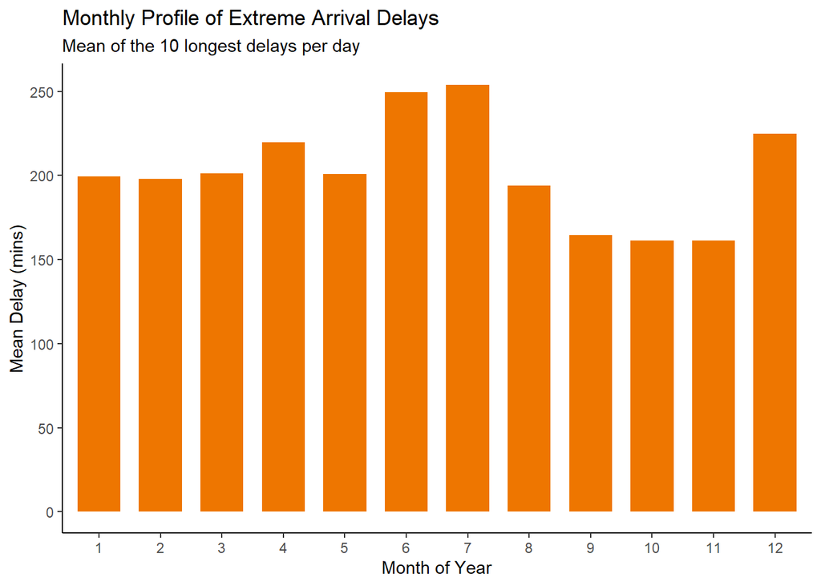

```r
ggplot(monthly_extremes, aes(x = factor(month), y = avg_delay)) +
  geom_col(fill = "darkorange2", width = 0.7) +
  labs(title = "Monthly Profile of Extreme Arrival Delays",
       subtitle = "Mean of the 10 longest delays per day",
       x = "Month of Year",
       y = "Mean Delay (mins)") +
  theme_classic()
```

## 2.3 Section 3

# 3 Exercise 3: Religion and Income Patterns

## 3.1 Section 1

```r
# Overview of structure
glimpse(relig_income)
```

```
Rows: 18
Columns: 11
$ religion             <chr> "Agnostic", "Atheist", "Buddhist", "Catholic", "D…
$ `<$10k`              <dbl> 27, 12, 27, 418, 15, 575, 1, 228, 20, 19, 289, 29…
$ `$10-20k`            <dbl> 34, 27, 21, 617, 14, 869, 9, 244, 27, 19, 495, 40…
$ `$20-30k`            <dbl> 60, 37, 30, 732, 15, 1064, 7, 236, 24, 25, 619, 4…
$ `$30-40k`            <dbl> 81, 52, 34, 670, 11, 982, 9, 238, 24, 25, 655, 51…
$ `$40-50k`            <dbl> 76, 35, 33, 638, 10, 881, 11, 197, 21, 30, 651, 5…
$ `$50-75k`            <dbl> 137, 70, 58, 1116, 35, 1486, 34, 223, 30, 95, 110…
$ `$75-100k`           <dbl> 122, 73, 62, 949, 21, 949, 47, 131, 15, 69, 939, …
$ `$100-150k`          <dbl> 109, 59, 39, 792, 17, 723, 48, 81, 11, 87, 753, 4…
$ `>150k`              <dbl> 84, 74, 53, 633, 18, 414, 54, 78, 6, 151, 634, 42…
$ `Don't know/refused` <dbl> 96, 76, 54, 1489, 116, 1529, 37, 339, 37, 162, 13…
```

```r
# Check for empty cells across the entire set
colSums(is.na(relig_income))
```

```
          religion              <$10k            $10-20k            $20-30k
                 0                  0                  0                  0
           $30-40k            $40-50k            $50-75k           $75-100k
                 0                  0                  0                  0
         $100-150k              >150k Don't know/refused
                 0                  0                  0
```

**relig_income** data set is a tibble with 18 rows and 11 columns.

## 3.2 Section 2

```r
?relig_income
```

*The data comes from a Pew Research Center survey and has two main variables;*

- *Religion*
- *Income categories*

## 3.3 Section 3

*We’ll pivot the data to make it long using the pivot_long() function, because, currently, the data is in a wide format, making it hard to visualize income distributions all through the different religious affliations.*

## 3.4 Section 4

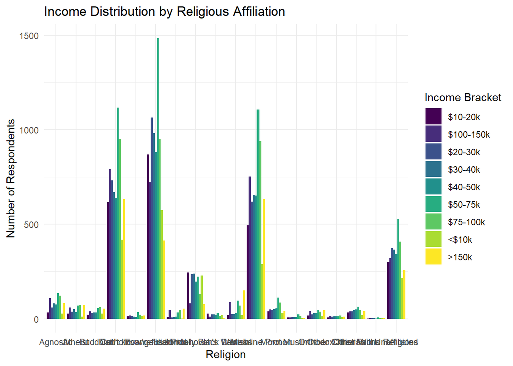

```r
library(tidyr)
library(ggplot2)
library(dplyr)

# Data reshaping (identical to original)
relig_long <- relig_income %>%
  pivot_longer(-religion, names_to = "income", values_to = "count") %>%
  filter(income != "Don't know/refused")

# Alternative grouped bar chart using geom_bar(stat = "identity")
ggplot(relig_long, aes(x = religion, y = count, fill = income)) +
  geom_bar(stat = "identity", position = position_dodge()) +
  scale_fill_viridis_d() +
  labs(title = "Income Distribution by Religious Affiliation",
       x = "Religion", y = "Number of Respondents", fill = "Income Bracket") +
  theme_minimal()
```

# 4 Exercise 4: US Rent and Income Correlation

## 4.1 Section 1

```r
# Summary
summary(us_rent_income)
```

```
    GEOID               NAME             variable            estimate
 Length:104         Length:104         Length:104         Min.   :  464.0
 Class :character   Class :character   Class :character   1st Qu.:  864.5
 Mode  :character   Mode  :character   Mode  :character   Median : 1507.0
                                                          Mean   :14923.1
                                                          3rd Qu.:28872.0
                                                          Max.   :43198.0
                                                          NA's   :1
      moe
 Min.   :  2.0
 1st Qu.:  4.5
 Median : 18.0
 Mean   : 95.5
 3rd Qu.:153.5
 Max.   :681.0
 NA's   :1
```

```r
# Quick dimensions and head
dim(us_rent_income)
```

```
[1] 104   5
```

```r
head(us_rent_income, 10)
```

```
# A tibble: 10 × 5
   GEOID NAME       variable estimate   moe
   <chr> <chr>      <chr>       <dbl> <dbl>
 1 01    Alabama    income      24476   136
 2 01    Alabama    rent          747     3
 3 02    Alaska     income      32940   508
 4 02    Alaska     rent         1200    13
 5 04    Arizona    income      27517   148
 6 04    Arizona    rent          972     4
 7 05    Arkansas   income      23789   165
 8 05    Arkansas   rent          709     5
 9 06    California income      29454   109
10 06    California rent         1358     3
```

## 4.2 Section 2

```r
?us_rent_income
```

The data was captured in a 2017 American Community Survey

Description of the data variables is as follows:

**GEOID** : FIP state identifier

**NAME:** Name of state

**variable:** Variable name: income = median yearly income, rent = median monthly rent

**estimate:** Estimated value

**moe:** 90% margin of error

## 4.3 Section 3

> *Currently the data is in a long format, so each states appears two times. We need to move the “variable” column into its own headers to allow for a scatter plot comparison using the **pivot_wider()*** function.

## 4.4 Section 4

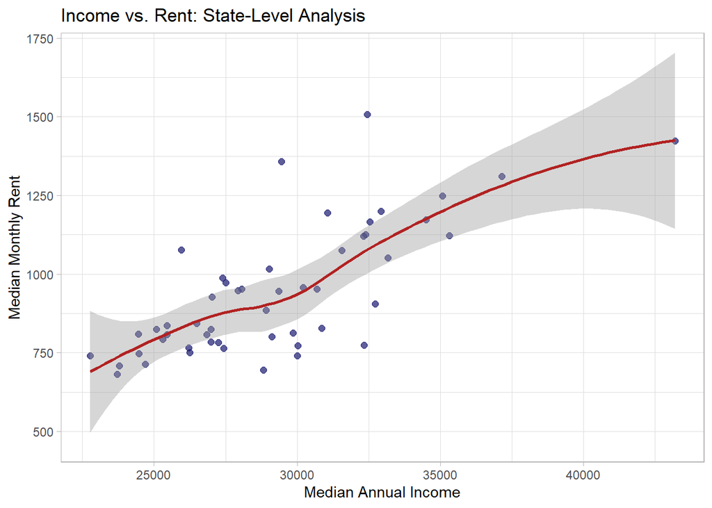

```r
# Widening the data
rent_wide <- us_rent_income %>%
  pivot_wider(names_from = variable, values_from = c(estimate, moe))

# Scatter plot with a regression trend
ggplot(rent_wide, aes(x = estimate_income, y = estimate_rent)) +
  geom_point(color = "midnightblue", size = 2, alpha = 0.7) +
  geom_smooth(method = "loess", color = "firebrick", se = TRUE) +
  labs(title = "Income vs. Rent: State-Level Analysis",
       x = "Median Annual Income",
       y = "Median Monthly Rent") +
  theme_light()
```

## 4.5 Section 5

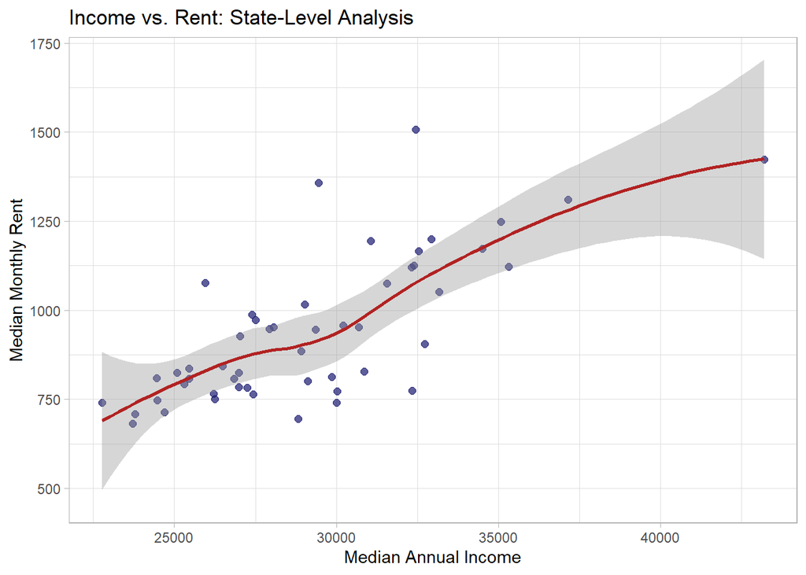

```r
# Widening the data
us_rent_income %>%
  pivot_wider(names_from = variable, values_from = c(estimate, moe))%>%
 ggplot(aes(x = estimate_income, y = estimate_rent)) +
  geom_point(color = "midnightblue", size = 2, alpha = 0.7) +
  geom_smooth(method = "loess", color = "firebrick", se = TRUE) +
  labs(title = "Income vs. Rent: State-Level Analysis",
       x = "Median Annual Income",
       y = "Median Monthly Rent") +
  theme_light()
```

# 5 Exercise 5: Sports Data Manipulation

```r
mba <- data.frame(
  player = c('A', 'A', 'B', 'B', 'C', 'C'),
  year   = c(1, 2, 1, 2, 1, 2),
  stats  = c('22/2/3', '29/3/4', '18/6/7', '11/1/2', '12/1/1', '19/2/4')
)
mba
```

```
  player year  stats
1      A    1 22/2/3
2      A    2 29/3/4
3      B    1 18/6/7
4      B    2 11/1/2
5      C    1 12/1/1
6      C    2 19/2/4
```

## 5.1 Section 1

```r
mba_sep <- mba %>%
  separate(stats, into = c("points", "assists", "steals"), sep = "/", convert = TRUE) #separating

mba_sep
```

```
  player year points assists steals
1      A    1     22       2      3
2      A    2     29       3      4
3      B    1     18       6      7
4      B    2     11       1      2
5      C    1     12       1      1
6      C    2     19       2      4
```

## 5.2 Section 2

```r
mba_uni <- mba_sep %>%
  unite(stats, points, assists, steals, sep = "-") #uniting

mba_uni
```

```
  player year  stats
1      A    1 22-2-3
2      A    2 29-3-4
3      B    1 18-6-7
4      B    2 11-1-2
5      C    1 12-1-1
6      C    2 19-2-4
```

# 6 Exercise 6: Table Generation with `gt`

## 6.1 Section 1

```r
library(gt)

# Finding the daily 'latest start' per month
late_starts <- flights %>%
  drop_na(dep_time) %>%
  group_by(month, day) %>%
  summarise(first_out = min(dep_time), .groups = "drop") %>%
  group_by(month) %>%
  slice_max(first_out, n = 1)

late_starts
```

```
# A tibble: 12 × 3
# Groups:   month [12]
   month   day first_out
   <int> <int>     <int>
 1     1    20       525
 2     2     9       901
 3     3     3       509
 4     4    30       455
 5     5    29       457
 6     6    15       456
 7     7     5        38
 8     8    31       455
 9     9    29       521
10    10     6       519
11    11     3       519
12    12    18       500
```

```r
# Generate a'fancy' table
late_starts %>%
  gt() %>%
  tab_header(title = "Monthly Peak for First Daily Departure") %>%
  cols_label(month = "Month", day = "Day", first_out = "Time") %>%
  data_color(columns = first_out, palette = "Greens")
```

Monthly Peak for First Daily Departure

[output not shown]

## 6.2 Section 2

```r
#head(flights, 5)

top_destinations <- flights %>%
  count(dest, sort = TRUE) %>% #count and sort
  slice_head(n = 5)

top_destinations %>%
  gt() %>%  # generate a quality table
  tab_header(title = "Top Five Destinations from New York")
```

Top Five Destinations from New York

| dest | n |
| --- | --- |
| ORD | 17283 |
| ATL | 17215 |
| LAX | 16174 |
| BOS | 15508 |
| MCO | 14082 |

The data makes sense since these are major cities that receive a lot of flights from New York City (NYC)

# 7 Exercise 7: Handling Missing Solar Radiation Data

```r
# imputing missing values with the median

# calculate the median
solar_median <- round(median(air.tib$Solar.R, na.rm = TRUE))
solar_median
```

```
[1] 205
```

```r
# replacing the NAs with the median
air_clean <- air.tib %>%
  replace_na(list(Solar.R = solar_median))

# Check if NAs are cleared
anyNA(air_clean$Solar.R)
```

```
[1] FALSE
```

# 8 Exercise 8: Temperature Analysis

```r
# total and maximum temperatures combined with label recoding
air_summary <- air_clean %>%
  mutate(Month_Label = month.name[Month]) %>% # Built-in R month names
  group_by(Month_Label) %>%
  summarise(
    Total_Heat = sum(Temp),
    Peak_Heat = max(Temp)
  )

head(air_summary)
```

```
# A tibble: 5 × 3
  Month_Label Total_Heat Peak_Heat
  <chr>            <int>     <int>
1 August            2603        97
2 July              2601        92
3 June              2373        93
4 May               2032        81
5 September         2307        93
```

# 9 Exercise 9: Temperature Analysis - Visual

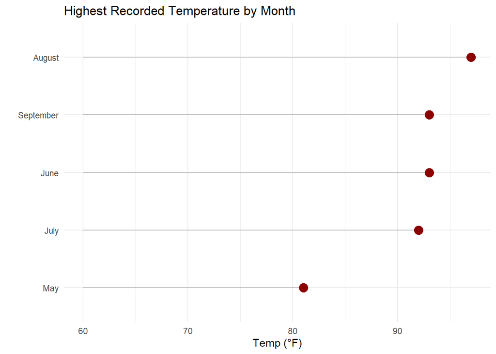

```r
# visualizing Max Temp
ggplot(air_summary, aes(x = Peak_Heat, y = reorder(Month_Label, Peak_Heat))) +
  geom_segment(aes(x = 60, xend = Peak_Heat, yend = Month_Label), color = "grey") +
  geom_point(size = 4, color = "darkred") +
  labs(title = "Highest Recorded Temperature by Month", x = "Temp (°F)", y = "") +
  theme_minimal()
```

# 10 Exercise 10: Multi-Variable Ozone Comparison

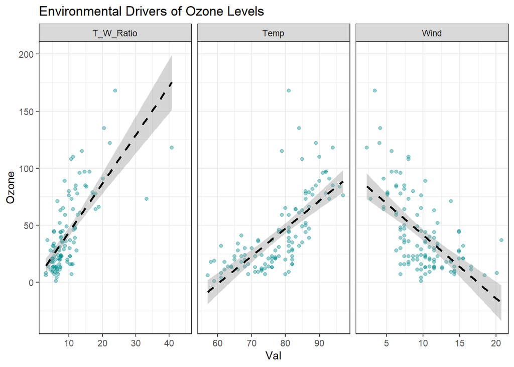

```r
air_clean %>%
  mutate(T_W_Ratio = Temp / Wind) %>%
  pivot_longer(cols = c(Temp, Wind, T_W_Ratio), names_to = "Metric", values_to = "Val") %>%
  ggplot(aes(x = Val, y = Ozone)) +
  geom_point(color = "darkcyan", alpha = 0.4) +
  geom_smooth(method = "lm", color = "black", linetype = "dashed") +
  facet_wrap(~Metric, scales = "free_x") +
  labs(title = "Environmental Drivers of Ozone Levels") +
  theme_bw()
```

*Interpretation*

*Ozone levels show a strong positive correlation with heat. Interestingly, wind acts as a diffuser, higher wind speeds are consistently linked to lower Ozone concentrations. The ratio provides a combined metric, but the individual variables offer clearer predictive power.*